# EDA: Analyse des particules fines

# Requêtes:

### Les émissions totales de PM2,5 ont-elles diminué aux USA de 1999 à 2008?

```r
# Requête 1
req_1 <- NEI_data %>% group_by(year) %>% summarise(total_emission = round(sum(Emissions),0))
req_1
```

```
## # A tibble: 4 x 2
##   year  total_emission
##   <chr>          <dbl>
## 1 1999         7332967
## 2 2002         5635780
## 3 2005         5454703
## 4 2008         3464206
```

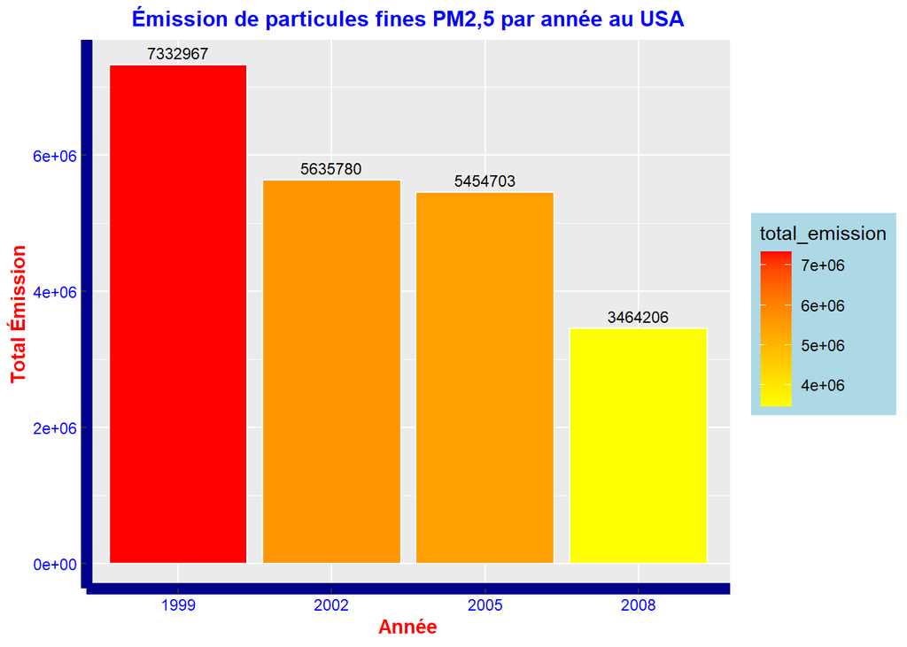

```r
# Graphe
emissions_par_an <- req_1 %>% ggplot(aes(year, total_emission, fill = total_emission)) +
                    geom_bar(stat = "identity", color = "white") +
                    geom_text(aes(label = total_emission, hjust = 0.5,vjust = -0.5), size = 3,color = 'black') +
                    xlab("Année") +
                    ylab("Total Émission") +
                    labs("Émission") +
                    scale_fill_gradient(low = "yellow", high = "red") +
                    ggtitle("Émission de particules fines PM2,5 par année au USA") +
                    theme(plot.title = element_text(color = "blue", hjust = 0.5,  face = "bold", size = 12),
                          axis.title.x = element_text(color = "red", face = "bold"),
                          axis.title.y = element_text(color = "red", face = "bold"),
                          axis.line = element_line(colour = "darkblue", size = 3, linetype = "solid"),
                          axis.text = element_text(color = "blue"),
                          legend.background = element_rect(fill = "lightblue",
                          size=0.5, linetype="solid", colour = "white"))


emissions_par_an
```

**Conclusion :** *D’après nos précédents résultats, on peut bien se rendre compte que les émissions de particules fines PM2,5 ont bel et bien diminué de 1999 à 2008!*

### Les émissions totales de PM2,5 ont-elles diminué dans la ville de Baltimore, Maryland (fips == “24510”) de 1999 à 2008?

```r
# Requête 2
req_2 <- NEI_data %>% filter(fips == "24510") %>% group_by(year) %>% summarise(total_emission = round(sum(Emissions),1))
req_2
```

```
## # A tibble: 4 x 2
##   year  total_emission
##   <chr>          <dbl>
## 1 1999           3274.
## 2 2002           2454.
## 3 2005           3091.
## 4 2008           1862.
```

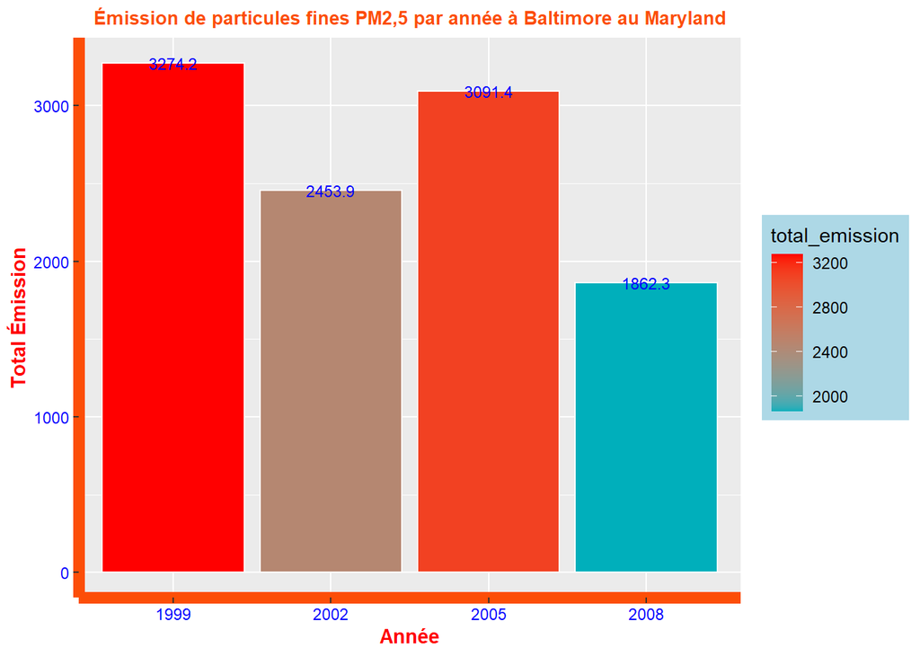

```r
# Graphe
pm_par_an_balt <- req_2 %>% ggplot(aes(year, total_emission, fill = total_emission)) +
                  geom_bar(stat = "identity", color = "white") +
                  geom_text(aes(label = total_emission), size = 3, color = 'blue') +
                  xlab("Année") +
                  ylab("Total Émission") +
                  scale_fill_gradient(low = "#00AFBB", high = "red") +
                  ggtitle("Émission de particules fines PM2,5 par année à Baltimore au Maryland") +
                  theme(plot.title = element_text(color = "#FC4E07", hjust = 0.5, face = "bold", size = 10),
                        axis.title.x = element_text(color = "red", face = "bold"),
                        axis.title.y = element_text(color = "red", face = "bold"),
                        axis.line = element_line(colour = "#FC4E07", size = 3, linetype = "solid"),
                        axis.text = element_text(color = "blue"),
                        legend.background = element_rect(fill = "lightblue",
                        size = 0.5, linetype = "solid", colour = "white"))


pm_par_an_balt
```

### Parmi les quatre types de sources indiqués par la variable de type (ponctuelle, non ponctuelle, routière, non routière), laquelle de ces quatre sources a connu une diminution des émissions de 1999 à 2008 pour la ville de Baltimore? Lesquels ont connu une augmentation des émissions de 1999 à 2008?

```r
# Requête 3
req_3 <- NEI_data %>% filter(fips == "24510") %>% group_by(year,type) %>% summarise(total_emission = round(sum(Emissions),1))
req_3
```

```
## # A tibble: 16 x 3
## # Groups:   year [4]
##    year  type     total_emission
##    <chr> <chr>             <dbl>
##  1 1999  NON-ROAD          523.
##  2 1999  NONPOINT         2108.
##  3 1999  ON-ROAD           347.
##  4 1999  POINT             297.
##  5 2002  NON-ROAD          241.
##  6 2002  NONPOINT         1510.
##  7 2002  ON-ROAD           134.
##  8 2002  POINT             569.
##  9 2005  NON-ROAD          249.
## 10 2005  NONPOINT         1510.
## 11 2005  ON-ROAD           130.
## 12 2005  POINT            1202.
## 13 2008  NON-ROAD           55.8
## 14 2008  NONPOINT         1373.
## 15 2008  ON-ROAD            88.3
## 16 2008  POINT             345
```

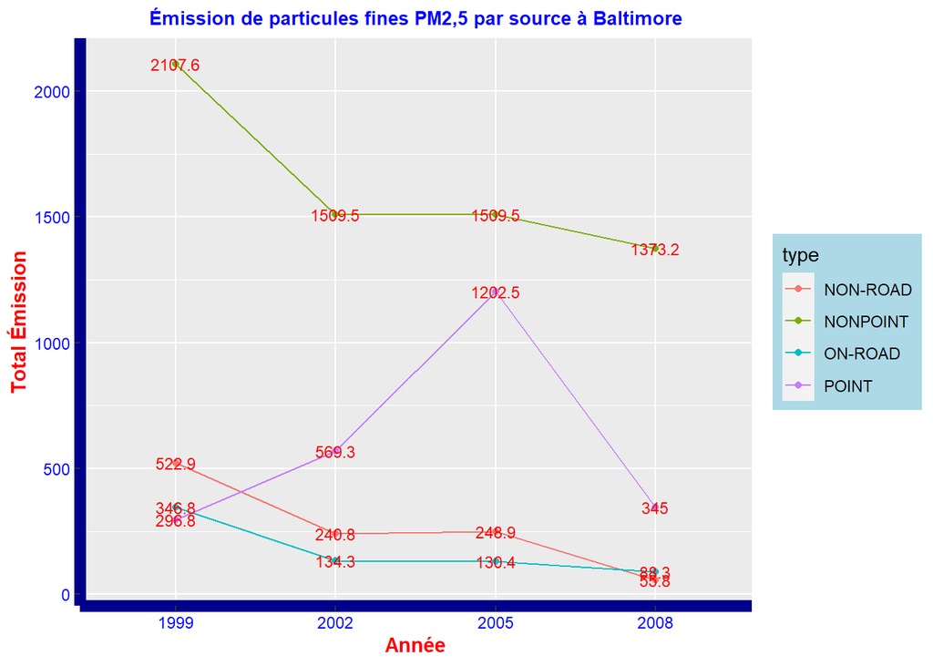

```r
# Graphe
pm_par_an_route_balt <- req_3 %>% ggplot(aes(year, total_emission, group = type, color = type)) +
                        geom_point() +
                        geom_line(linetype = "solid", alpha = 1) +
                        geom_text(aes(label = total_emission), size = 3, color = 'red', face = "bold") +
                        xlab("Année") +
                        ylab("Total Émission") +
                        scale_fill_gradient(low = "darkblue", high = "blue") +
                        ggtitle("Émission de particules fines PM2,5 par source à Baltimore") +
                        theme(plot.title = element_text(color = "blue", hjust = 0.5, face = "bold", size = 10),
                              axis.title.x = element_text(color = "red", face = "bold"),
                              axis.title.y = element_text(color = "red", face = "bold"),
                              axis.line = element_line(colour = "darkblue", size = 3, linetype = "solid"),
                              axis.text = element_text(color = "blue"),
                              legend.background = element_rect(fill = "lightblue",
                              size = 0.5, linetype = "solid", colour = "white"))
pm_par_an_route_balt
```

**Conclusion :** *D’après nos précédents résultats, on peut bien voir que les routes ayant subit des diminutions des émissions de 1999 à 2008 sont: NonPoint, On-Road, Non-Road.*

### Partout aux États-Unis, comment les émissions provenant de sources liées à la combustion du charbon ont-elles changé entre 1999 et 2008?

```r
# Lignes liée à la combustion du charbon
# >str <- c("Regular", "expression", "examples of R language")
# >x <- grepl("x*ress",str)
charbon <- grepl("coal", SCC_data$Short.Name, ignore.case = TRUE) | grepl("coal", SCC_data$EI.Sector,ignore.case = TRUE)

# Sélection des lignes liée à la combustion du charbon dans un nouveau dataframe
charbon <- SCC_data[charbon, ]
charbon <- NEI_data[NEI_data$SCC %in% charbon$SCC,]

# Requête 4
req_4 <- charbon %>% group_by(year) %>% summarise(total_emission = round(sum(Emissions),1))
req_4
```

```
## # A tibble: 4 x 2
##   year  total_emission
##   <chr>          <dbl>
## 1 1999         604691.
## 2 2002         567130.
## 3 2005         571768.
## 4 2008         358219.
```

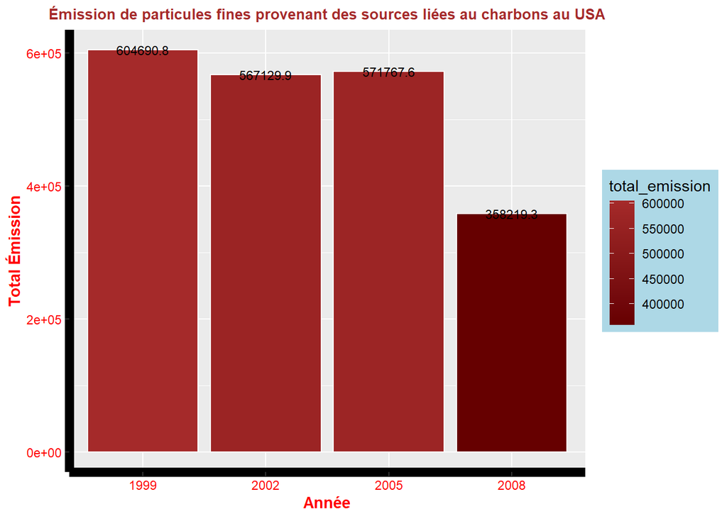

```r
# Graphe
pm_charbon_USA <- req_4 %>% ggplot(aes(year, total_emission, fill = total_emission)) +
                  geom_bar(stat = "identity", color = "white") +
                  geom_text(aes(label = total_emission), size = 3, color = 'black') +
                  xlab("Année") +
                  ylab("Total Émission") +
                  scale_fill_gradient(low = "#660000", high = "brown") +
                  ggtitle("Émission de particules fines provenant des sources liées au charbons au USA") +
                  theme(plot.title = element_text(color = "brown", hjust = 0.5, face = "bold", size = 10),
                        axis.title.x = element_text(color = "red", face = "bold"),
                        axis.title.y = element_text(color = "red", face = "bold"),
                        axis.line = element_line(colour = "black", size = 3, linetype = "solid"),
                        axis.text = element_text(color = "red"),
                        legend.background = element_rect(fill = "lightblue",
                        size = 0.5, linetype = "solid", colour = "white"))


pm_charbon_USA
```

### Comment les émissions des véhicules à moteur ont-elles changé de 1999 à 2008 dans la ville de Baltimore?

```r
req_5 <- NEI_data %>% filter(fips == "24510" & type == "ON-ROAD") %>% group_by(year) %>% summarise(total_emission = round(sum(Emissions),1))
req_5
```

```
## # A tibble: 4 x 2
##   year  total_emission
##   <chr>          <dbl>
## 1 1999           347.
## 2 2002           134.
## 3 2005           130.
## 4 2008            88.3
```

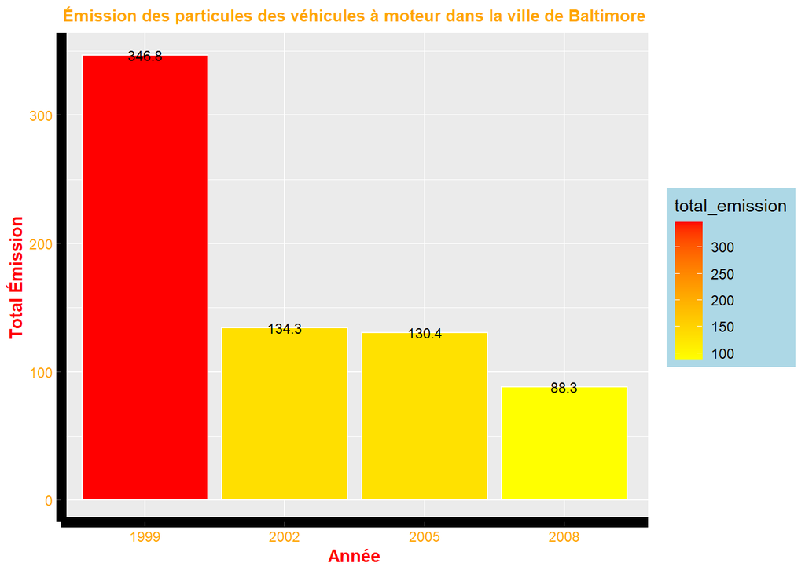

```r
# Graphe
pm_moteur_baltimore <- req_5 %>% ggplot(aes(year, total_emission, fill = total_emission)) +
                       geom_bar(stat = "identity", color = "white") +
                       geom_text(aes(label = total_emission), size = 3, color = 'black') +
                       xlab("Année") +
                       ylab("Total Émission") +
                       scale_fill_gradient(low = "#FFFF00", high = "#ff0000") +
                       ggtitle("Émission des particules des véhicules à moteur dans la ville de Baltimore") +
                       theme(plot.title = element_text(color = "orange", hjust = 0.5, face = "bold", size = 10),
                             axis.title.x = element_text(color = "red", face = "bold"),
                             axis.title.y = element_text(color = "red", face = "bold"),
                             axis.line = element_line(colour = "black", size = 3, linetype = "solid"),
                             axis.text = element_text(color = "orange"),
                             legend.background = element_rect(fill = "lightblue",
                             size = 0.5, linetype = "solid", colour = "white"))


pm_moteur_baltimore
```

**Conclusion :** *D’après nos précédents résultats, on constater que les Émissions de particules PM2,5 des véhicules à moteur dans la ville de Baltimore ont diminué de manière abyssal de 1999 à 2008.*

### Comparez les émissions provenant de sources de véhicules à moteur dans la ville de Baltimore avec les émissions de sources de véhicules à moteur dans le comté de Los Angeles, Californie (fips == 06037). Quelle ville a connu des changements plus importants au fil du temps dans les émissions des véhicules à moteur?

```r
req_6 <- NEI_data %>% filter((fips == "24510" | fips == "06037") & type == "ON-ROAD") %>% group_by(year,fips) %>% summarise(total_emission = round(sum(Emissions),0)) %>% mutate(fips = replace(fips, fips == "24510","Baltimore") , fips = replace(fips, fips == "06037","Californie") )
req_6
```

```
## # A tibble: 8 x 3
## # Groups:   year [4]
##   year  fips       total_emission
##   <chr> <chr>               <dbl>
## 1 1999  Californie           3931
## 2 1999  Baltimore             347
## 3 2002  Californie           4274
## 4 2002  Baltimore             134
## 5 2005  Californie           4601
## 6 2005  Baltimore             130
## 7 2008  Californie           4101
## 8 2008  Baltimore              88
```

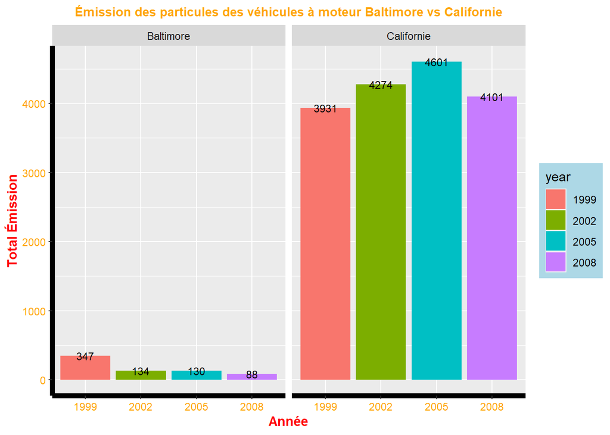

```r
# Graphe
pm_baltimore_vs_Cal <- req_6 %>% ggplot(aes(year, total_emission)) +
                       facet_grid(~fips) +
                       geom_bar(stat = "identity",aes(fill = year)) +
                       geom_text(aes(label = total_emission), size = 3, color = 'black') +
                       xlab("Année") +
                       ylab("Total Émission") +
                       ggtitle("Émission des particules des véhicules à moteur Baltimore vs Californie") +
                       theme(plot.title = element_text(color = "orange", hjust = 0.5, face = "bold", size = 10),
                             axis.title.x = element_text(color = "red", face = "bold"),
                             axis.title.y = element_text(color = "red", face = "bold"),
                             axis.line = element_line(colour = "black", size = 2, linetype = "solid"),
                             axis.text = element_text(color = "orange"),
                             legend.background = element_rect(fill = "lightblue",
                             size = 0.5, linetype = "solid", colour = "white"))


pm_baltimore_vs_Cal
```

**Conclusion :** *D’après nos précédents résultats, on constater que les Émissions de particules PM2,5 des véhicules à moteur dans la ville de Baltimore ont diminué de manière abyssal de 1999 à 2008, ce qui est complètement différent en Californie où on peut voir une augmentation d’émission de particules 1999 à 2005 puis une dimunition de 2005 à 2008.* *On peut en déduire qu’il est préférable de vivre à Baltimore que en Californie si on veut pas être exposé aux particules fines.*